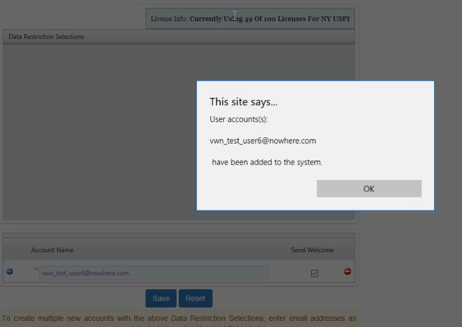

1. When you go and look at the individual record to confirm the user addition and data restriction, the status appears as **Password Reset**.

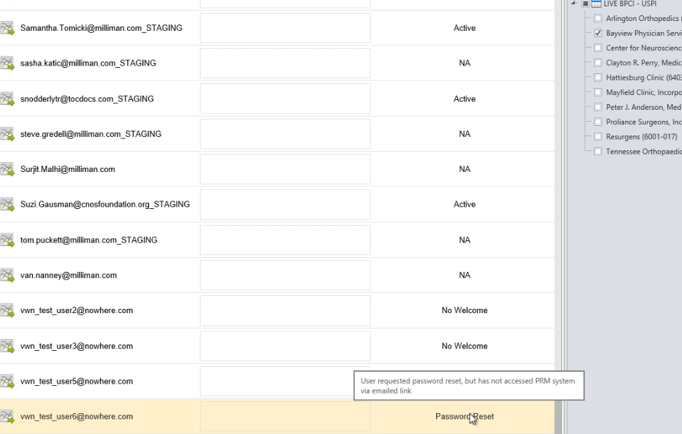

1. The reason for this is, that the first time a new user logs in, they have to change their password via the **Send Welcome** email they receive with a secure link.

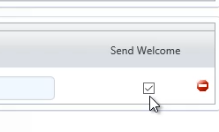

> Example **Send Welcome** email.

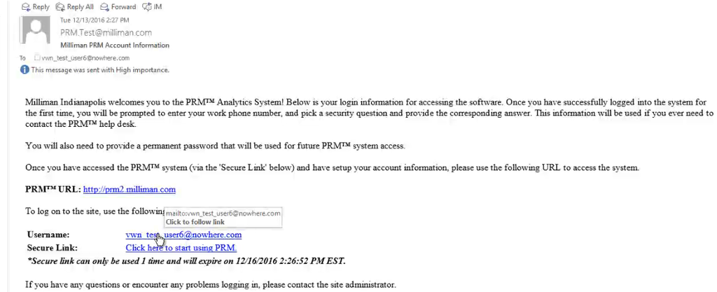

1. As an alternative for clients who prefer a manual email reset, you may place a bracket within the account name before hitting **Save** and uncheck **the Send Welcome** box.

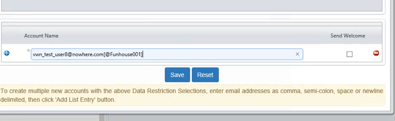

1. This will add the user to the system and then you can send them a manual email with their bracketed password.

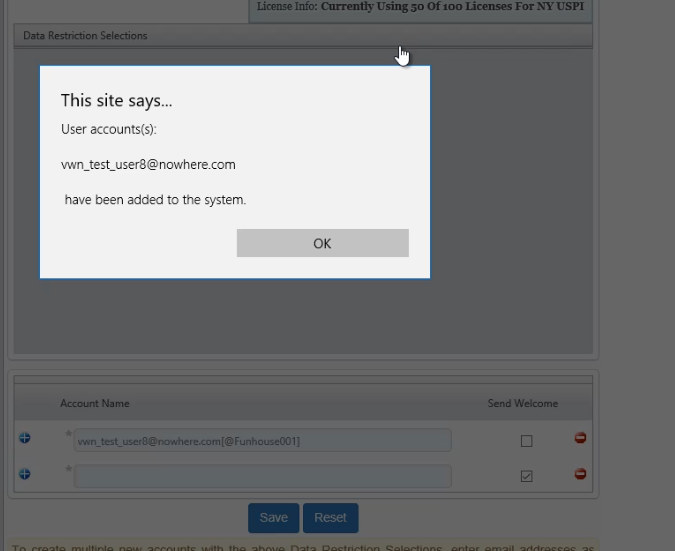

1. Using the + buttons at the bottom left, you can add multiple users.

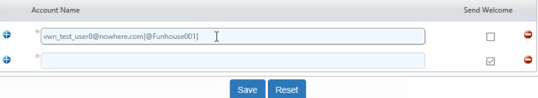

1. **Note: If you accidentally add a name for an existing account, it will just add any new information to the existing account and not create a second record**.
2. This dialog box appears after action to allow the user to refresh their browser.

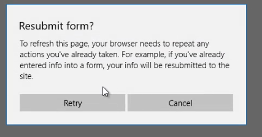

1. In the case where a manual email is sent to the user and they log in without the link in the Welcome email, they will receive this prompt the first time they log in.

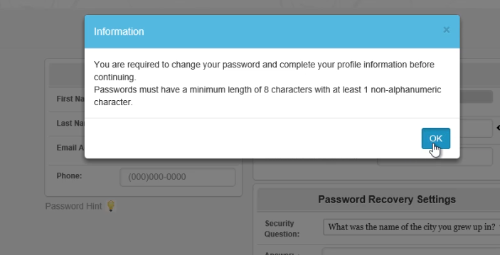

1. At this point, they will change their password and answer a **Security Question** as part of the **Password Recovery Settings**.

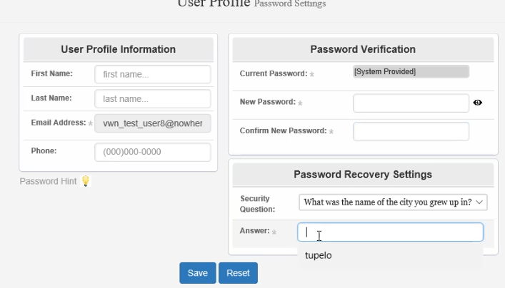